# Analyse Univariée (avec R)

2019-2020

## Introduction générale

## Avertissement

⚠ Pour voir les formules, une connexion internet est requise. ⚠

## Reférences

- Cours M2 IGAST 2018 d'Ana-Maria Olteanu-Raimond
- R et espace https://framabook.org/r-et-espace/
- Probabilités, analyse de données et statistiques , Gilbert Saporta, Editions TECHNIP, 2011
- Nombreuses ressources en ligne, e.g. : http://www.foad-mooc.auf.org/IMG/pdf/424B_-Application_des_methodes_statistiques_d_analyse.pdf

## Deux familles statistiques

### Statistiques inférentielles

A partir d'un échantillon , que peut-on attendre (=**inférer**) de la population ?

- Modèles, estimateurs, … : **régression**, **estimation**, **extrapolation**
- e.g. sondages, rencensement

## Deux familles statistiques

### Statistiques descriptives

Pour décrire, résumer, synthétiser les propriétés d'une **population** à partir de ses **individus** et des **variables** qui les décrivent.

- Graphiques
- Mesures (fréquences, distributions, moments) sur des variables
- *Liaisons* statistiques entre variables : **corrélation**, **covariance**
- classification , ACP,…

## Au programme dans ce module

Nous ferons majoritairement de la statistique **descriptive**

(même si, pour bien décrire, il faut parfois inférer)

## Vocabulaire

### Population

**Ensemble** d'individus

"données", "corpus", "échantillon", "data"

### Individus

**Unité** statistique **élémentaire**: personnes, logements, …

\(\rightarrow\) "les lignes du tableau"

## Vocabulaire

### Variables

**Caractéristiques, propriétés** d’un individu, mesurées par des enquêtes, des observations…

"les colonnes du tableau"

- **Qualitatives** : facteurs e.g. Sexe, CSP, type , notion de **modalité**
- **Quantitatives** : nombres e.g. Taille, revenu, surface

⚠ **Valeurs** et **Nature** de données sont deux choses distinctes.

3≠trois≠III

⚠ Valeurs manquantes

NA , NaN, Null

## Analyse univariée

**Décrire** et **mesurer** la **répartition** des valeurs que peut prendre une variable.

On parle de **distributions** (\(\approx\) "histogramme en continu")

Parfois certaines de ces répartitions s'approchent de distributions bien connues (des **modèles**) : on parle de **lois**

e.g. loi normale/gaussienne , loi de Poisson

## Histogramme d'une variable suivant une loi normale \(\mathscr{N}(0,1)\)

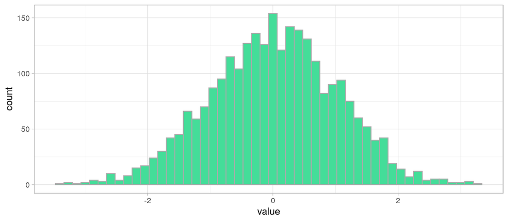

```r
xx <- data.frame(value=rnorm(2600))
plot1 <- ggplot(xx)+
        geom_histogram(aes(x = value),bins = 50, color="#aaaaaa", fill="#44DD99" )+
        theme_light()
plot1
```

## Histogramme d'une distribution asymetrique à longue traîne.

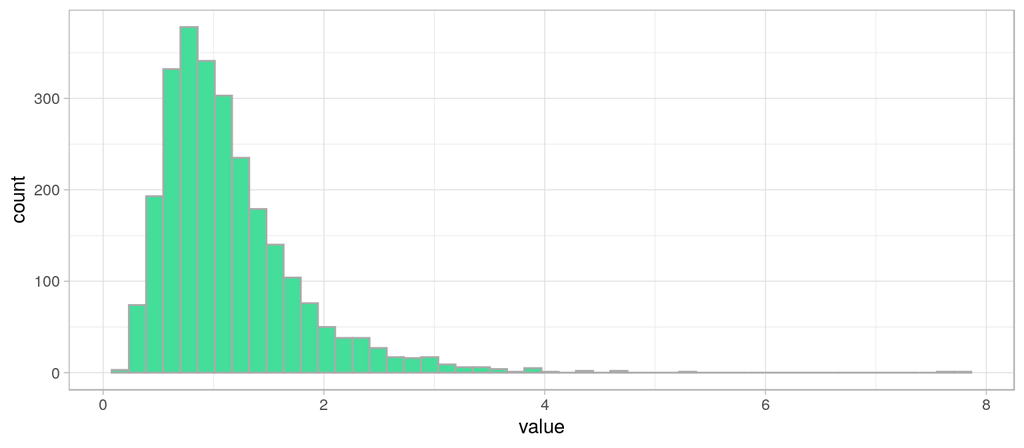

```r
xx <- data.frame(value=rlnorm(2600,sdlog = 0.5))
plot1 <- ggplot(xx)+
        geom_histogram(aes(x = value),bins = 50, color="#aaaaaa", fill="#44DD99" )+
        theme_light()
plot1
```

## Les pièges de la statistique

> « Les statistiques ont une particularité majeure: elles ne sont jamais les mêmes selon qu’elles sont avancées par un homme de gauche ou par un homme de droite.»

Jacques Mailhot

## Les pièges de la statistique : exemple 1

Dette 2013 = 100 milliards €

Article de 2015 n°1 : « Diminution du déficit: La dette de la France, qui avait augmenté de 15 % l’an passé, n’a augmenté cette année que de 14%. Le gouvernement se félicite de sa gestion exemplaire.»

Article de 2015 n°2 : « Augmentation du déficit: 15 milliard l’an passé, il dépasserait cette année 16 milliard €»

Qui dit la vérité?

## Les pièges de la statistique: exemple 2

Sur les mêmes chiffres du bilan d’une entreprise en 2013 et 2014

- syndicats: «tous les salaires ont baissé de 10%»
- dirigeants: «le salaire moyen a augmenté d’environ 18%»

|  | Ouvriers | Cadres |
| --- | --- | --- |
| 2013 | effectif : 500 | effectif : 100 |
|  | salaire : 1300 | salaire :2200 |
| 2014 | effectif : 200 | effectif : 400 |
|  | salaire :1170 | salaire : 1980 |

## Les précautions à prendre

### Taille et représentativité de l'échantillon

### Présences de groupes (paradoxe de Simpsons)

## Analyse univariée

Objectif : **Décrire la répartition des valeurs** d'une variable

### Mesures de **tendance centrale**

mode, moyenne, médiane

### Mesures de **dispersion**

étendue, écart-type, variance, quantiles, coefficient de variation

### Mesures de **forme**

symétrie (Skewness) et aplatissement (Kurtosis)

## Les variables (1)

### Données "non spatiales""

Les variables sont des valeurs attributaires d'individus, leurs localisation n'est pas prise en compte

### Données spatiales

Individus restreints spatialement (**selection spatiale**), ou variables de **localisation** géographique (e.g. Lieu de résidence, coordonnées) renseignées pour les individus

quid des **distances** ? \(\rightarrow\) modèle gravitaire , réseau etc.

## Variables **quantitatives**

Exemple ?

### variables quantitatives **continues** : \(var \in \mathbb{R}\)

Valeurs réelles, toutes les valeurs de l'intervalle de mesures peuvent exister

### variables quantitatives **discrètes** : \(var \in \mathbb{N}\)

Valeurs entières, pour des attributs **dénombrables** (comptage) ,

parfois utilisées pour encoder une variable qualitative à 2 modalité e.g. présence (1) , absence(0)

## Variables **qualitatives**

Exemple ?

les valeurs sont prises dans un ensemble **fini** de valeurs possibles, défini par **extension** (i.e. on donne la liste des valeurs possibles)

\(\rightarrow\) notion de **modalités**

## Variables **qualitatives**

### variables qualitatives **nominales**

Les modalités ne sont **pas ordonnées** explicitement

e.g. situation matrimoniale \(\in\) {marié·e, célibataire, veuf·ve}

### variables qualitatives **ordinales**

Les modalités sont **ordonnées** selon un ordre **total** et non-ambigu.

e.g. Echelle de Likert (5 ou 7 valeurs, dont une neutre)

satisfaction \(\in\) {Très satisfait, Satisfait, Ni satisfait ni insatisfait, Peu satisfait, Pas du tout satisfait}

## l'Échelle d’Analyse

Spécificité de la statistique spatiale : à quelle échelle observe-t'on une donnée ?

«Problème insoluble» : le MAUP (Modifiable Areal Unit Problem)

### Unités spatiales agrégées

agrégation d’unités spatiales : comtés, départements, régions, pays

e.g. Comprendre comment le taux de chômage d’un pays est distribué entre les régions pour guider les politiques économiques

### Groupe d’unités spatiales:

identification des unités spatiales ayant des caractéristiques semblables

e.g. IRIS

## Echelle d’analyse individuelle vs. Echelle d’analyse agrégée

Inférer à partir de l’analyse de données agrégées des caractéristiques individuelles **Désagrégation** ou **Ventilation**

Inférer des caractéristiques concernant les unités agrégées d’après les caractéristiques individuelles: **Agrégation**

⚠pas toujours possible et pas immédiat ! ⚠

## le MAUP (Modifibale Aereal Unit Problème)

Problème d'agrégation spatiale : les résultas d'une analyse statistique spatiale dépendent du choix d'agragation

biais «sytématique et insoluble»

## Statistiques descriptives univariées : la tendance

## Moyenne

### Moyenne

\(\displaystyle \bar{x} = \frac{1}{n}\sum_{i=0}^{n} x_i\)

### Moyenne pondérée

Lors que les valeurs n'ont pas le même poids (e.g. poids = effectif de la valeur)

\(\displaystyle \bar{x} = \frac{1}{\sum_{i=0}^n pi}\sum_{i=0}^{n} p_i x_i\)

## Avantages et inconvénients de la moyenne

### Avantage

Chaque valeur compte

### Inconvénients

- sensibilité aux valeurs extrèmes
- pas de signification sur les valeurs discrètes (e.g. 2.5 enfants par femme)

\(\rightarrow\) exclure les outliers  
\(\rightarrow\) utiliser un autre estimateur  
\(\rightarrow\) étudier la distribution des valeurs (e.g. cas bimodal) et opérer une classification

## Autres Moyennes

### Moyenne geométrique:

\(\displaystyle \bar{x} = \sqrt[n]{\prod _{i=0}^{n} x_i}\)

Moins sensible à la présence de valeurs extrèmes

### Moyenne quadratique (RMS)

\(\displaystyle \bar{x} = \sqrt{\frac{1}{n}\prod _{i=0}^{n} x_i}\)

## Moyennes glissantes

Moyenne calculée sur une fenètre de \(n\) valeurs consécutives.

e.g. on reçoit une mesure chaque seconde, très bruitée, et on désire afficher 10 minutes de signal lissé dans le temps

\(\rightarrow\) on calcule pour chaque point du signal, la moyenne sur 10 valeurs consécutives (5 en avant , 5 en arrière)

## le Mode

**Mode** : valeur la plus fréquente (effectif max.) de la série de valeurs que prend une variable.  
⚠ si variable quantitative continue ⚠

\(\rightarrow\) nécessite une classification préalable

Dans ce cas le mode est la moyenne des valeurs min et max des bornes de la classe de plus grand effectif.

## Avantages et inconvénients du mode

### Avantages

Peu sensible aux valeurs extrêmes (moins sensible que la moyenne) Signification concrète : la situation la plus fréquente

### Inconvénients

Ne dépends pas de toutes les observations : la modification d'une seule valeur n’entraine pas une modification du mode

## la Médiane

**Médiane** : valeur qui partage une série de valeurs en deux sous-ensembles d’égal effectif

Comme en géométrie, la médiane est la valeur de la variable qui est la plus proche de toutes les autres.

### Etapes de calcul

Ordonner les valeurs selon un ordre croissant

Calculer le rang \(i=\frac{n+1}{2}\)$

si \(n\) impair, la valeur médiane existe dans la série statistique

si \(n\) pair, la valeur médiane est entre deux valeurs et est égale à la moyenne de ces deux valeurs

## Avantages et inconvénients de la médiane

### Avantages

Plus pertinente que la moyenne

Peu sensible aux valeurs extrêmes

A une signification concrète : qui divise en deux la distribution : un individu sur deux a une valeur inférieure ou supérieure à celle-ci

### Inconvénient

Ne dépend pas de toutes les observations : la modification d'une seule valeur n’entraine pas une modification de la médiane

## Quelle mesure choisir ?

Tout dépend de la distribution !

\(\rightarrow\) **Toujours** afficher l'histogramme ou la distribution de densité

Le **mode** est privilégié pour les valeurs **nominales** et si on désire considérer «le cas le plus fréquent»

Distributions de variables continues sans longues traines ?  
\(\rightarrow\) moyenne et médiane

Plusieurs modes dans la distribution ?  
\(\rightarrow\) classification puis mediane / moyenne par classe

## Distribution bimodale

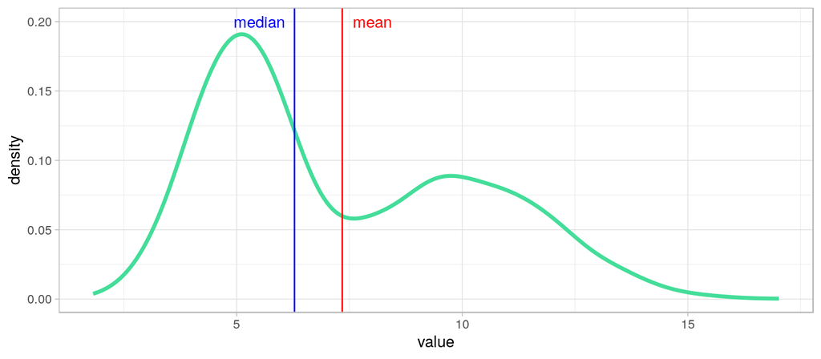

Que choisir : moyenne ou médiane ?

## Distribution unimodale symétrique

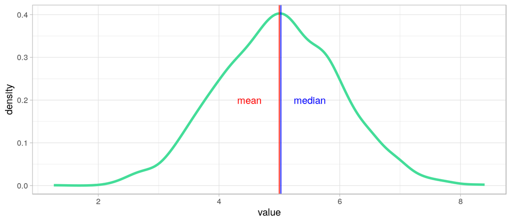

```r
xx <- data.frame(value=rnorm(2900,mean = 5, sd = 1))
plot1 <- ggplot(xx)+
        geom_line(aes(x = value),stat = "density", color="#44DD99", lwd= 1.3)+
        geom_vline(xintercept = mean(xx$value), color="red")+
        geom_vline(xintercept = median(xx$value) + 0.02,color="blue")+
        annotate("text", x=c(4.5,5.5), y=c(0.2,0.2), colour=c("red","blue"),label=c("mean", "median"))+
        theme_light()
plot1
```

## Statistiques descriptives univariées : la dispersion

## La dispersion statistique

Tendance des valeurs d'une variable à se disperser autour des valeurs des tendances centrales.

Exemple : deux variables X et Y, \(\sim\mathscr{N}(0,1)\)

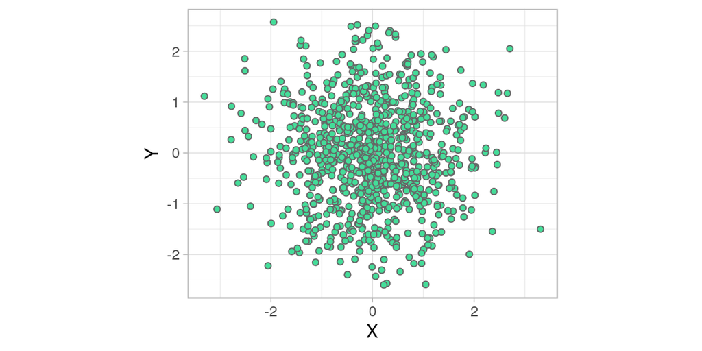

```r
mydataset <- data.frame(X=rnorm(900), Y=rnorm(900))
plot1 <- ggplot(mydataset)+
        geom_point(aes(x = X, y=Y), fill="#44DD99", color="#666666", shape=21)+
        coord_equal()+theme_light()
plot1
```

## Variance et Écart-type

La **variance** est la somme des écarts carrés à la moyenne

\(\displaystyle var_X= \frac{1}{n}\sum_{i=1}^{n}(x_i -\bar{x})^2\)

Avec :

- \(X\) une variable
- \(x_i\) les valeurs de la variables
- \(\bar{x}\) la moyenne de \(X\)
- \(n\) l'effectif

\(\sigma_X = \sqrt{var_X}\) : l'**écart type** est la racine carrée de la variance

## Variance et Écart-type

Variance et écart-type rendent compte de la **dispersion** de la variable autour de sa moyenne.

Ils sont **sensibles** aux valeurs extrèmes et toujours **positifs**.

Si \(var_X = 0\) ou \(\sigma_X = 0\) , alors \(X\) est **constante**.

Un écart-type faible indique que les valeurs sont réparties de façon **homogène** autour de la moyenne.

## Mise en garde

⚠ Variance et écart type n'ont d'intérêt que pour qualifier des distributions **unimodales**, et (à peu près) **symétriques** ⚠

(i.e. proche de la Gaussienne)

## Lorsque \(X\sim \mathscr{N}(\mu,\sigma)\)

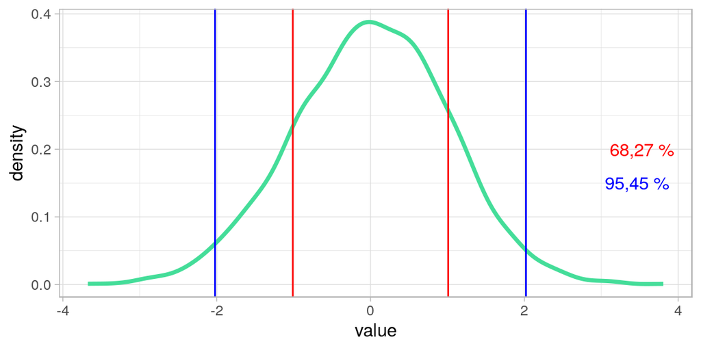

```r
X <- data.frame(value=rnorm(1900))
plot1 <- ggplot(X)+
        geom_line(aes(x = value),stat="density", color="#44DD99", lwd=1.2)+
        geom_vline(xintercept = c(-sd(X$value), sd(X$value)), color="red")+
        geom_vline(xintercept = c(-2*sd(X$value), 2*sd(X$value)), color="blue")+
        annotate("text", x=c(3.5,3.5), y=c(0.2,0.15), colour=c("red","blue"),label=c("  68,27 % ","95,45 % "))+
        theme_light()
plot1
```

## Quantiles

La **médiane** sépare une population en **2** classes d'égal effectif selon la valeur d'une variable quantitative.

Les **quantiles** séparent une population en **\(n\)** classes d'égal effectif.

Les **quartiles** d'une population selon une variable \(X\) sont 3 valeurs, \(Q_1,Q_2,Q3\) qui séparent la population en 4 classes d'égal effectif.

- 25% des valeurs de \(X\) sont strictement inférieures à \(Q_1\)
- 50% des valeurs de \(X\) sont strictement inférieures à \(Q_2\) (médiane)
- 75% des valeurs de \(X\) sont strictement inférieures à \(Q_3\)

## Déciles

Les déciles sont les **9** quantiles \(Q_1,Q_2,\dots,Q_9\) qui séparent une population selon la valeur d'une variable quantitative en **10** classes d'égal effectif.

## Ecarts inter-quartiles et inter-déciles

Deux mesures de la **dispersion** d'une distribution :

**Écart inter-quartile**: \(Q_3-Q_1\) , capture 50% des valeurs de la population les plus proches de la médiane

**Écart inter-déciile**: \(Q_9-Q_1\) , capture 80% des valeurs de la population les plus proches de la médiane

## Les boîtes à moustaches (boxplots)

représentation courante de la dispersion d'une variable à l'aide de **quartiles**

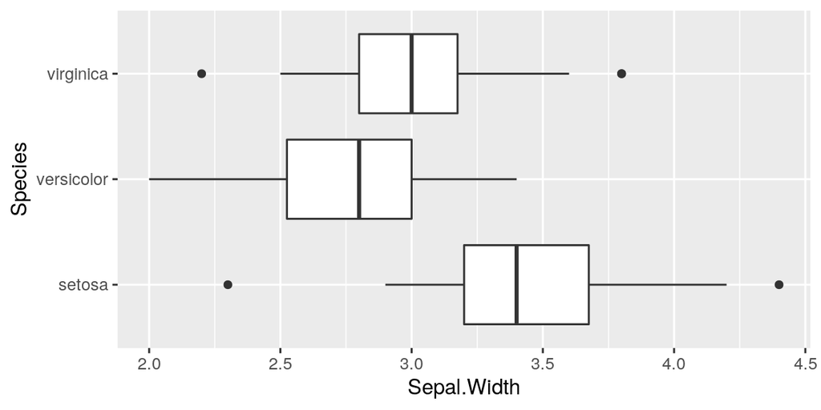

```r
plot1 <- ggplot(iris)+
  geom_boxplot(aes(y=Sepal.Width,x= Species) ) + coord_flip()
plot1
```

## Avantages et inconvénient des quantiles

### Avantages

Peu sensibles aux distributions aplaties et aux valeurs extrèmes

L'écart inter-quantile est plus robuste que l'écart-type

### Inconvénients

Parfois délicat pour les variables quantitatives discrètes

Les écarts inter-quantiles négligent l'influence des valeurs extrèmes sur la distribution

## Le coefficient de variation

Le coefficient de variation (\(CV\)) est une autre mesure de **dispersion** .

C'est le ratio entre l'écart-type \(\sigma_x\) et la moyenne \(\bar{x}\) d'une variable quantitative X.

\(\displaystyle CV(X)=\frac{\sigma_x}{\bar{x}}\)

Plus il est important , plus la dispersion est grande.

Plus il est proche de 0, plus les données sont homogènes.

Il souffre des mêmes inconvénients que la moyenne et l'écart-type : sensibilité aux valeurs extrèmes.

## Comparaison de dispersion de deux distributions de valeurs.

Exemple : deux communes versent des aides aux entreprises locales.

Commune A : moyenne = 390 euros, \(\sigma\) = 30 euros

Commune B : moyenne = 152 euros, \(\sigma\) = 8 euros

Pour quelle commune les aides sont les plus homogènes?

On peut aussi comparer des distribution de valeurs exprimées dans des unités différentes !

## Statistiques descriptives univariées : la forme

## Asymétrie des distributions.

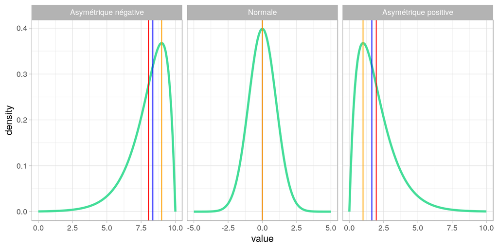

## les Coefficients de Pearson

2 moyens simples d'estimer l'asymétrie

\(\displaystyle C_1 = \frac{\bar{x} - mode(X)}{\sigma_x}\)

\(\displaystyle C_2 = \frac{3(\bar{x} - mediane(X))}{\sigma_x}\)

## Le coefficient de Fischer

Le coefficient est le moment d'ordre 3 de la variable \(X\) ( de moyenne \(\mu\) et d'écart-type \(\sigma\)) **centrée réduite**

\(\displaystyle skewness'=\mathbb{E}\bigg[\bigg(\frac{X-\mu}{\sigma}\bigg)^3\bigg]=\frac{\sum_{i=0}^{n} (x_i - \bar{x})^3}{n\sigma^3}\)

## L'aplatissement des distributions (kurtosis)

## Transormations des données

## Fat-tail distributions

Les distributions très asymétriques et très étendues sont délicates à résumer : les indicateurs traditionnels sont plus efficaces lorsque la variabilité des valeurs est moindre, et leur distribution plus symétrique.

e.g. Considérer la population moyenne des villes de France a-t'elle du sens ?

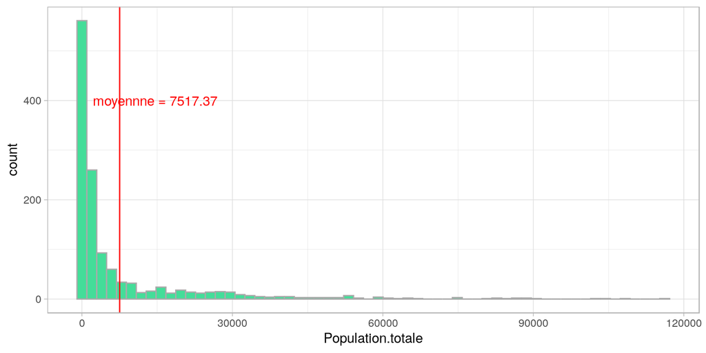

## Distribution rang-taille des villes de france

Pour mieux voir la distribution et les écarts, on trace la **taille** des villes en fonction de leur **rang**

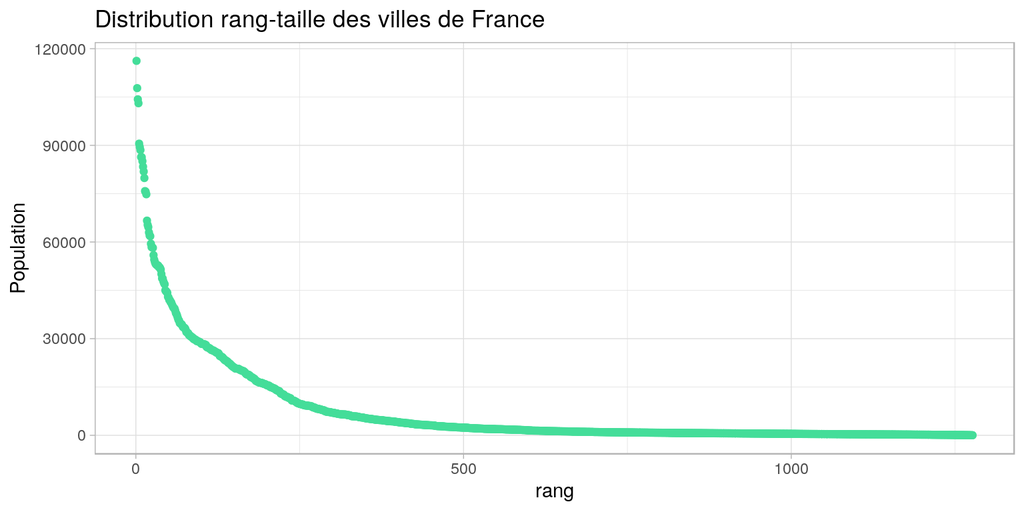

## Transformation logarithmique

Appliquer une transformation **monotone**, **bijective** et **inversible** qui "applatisse" la distribution , de façon à réduire les écarts entre les valeurs, et à resserrer l'essentiel des valeurs , pour mesurer de façon plus robuste leur tendance, dispersion et forme

Ici : le logarithme décimal

## Bonus : distribution rang-log(taille)

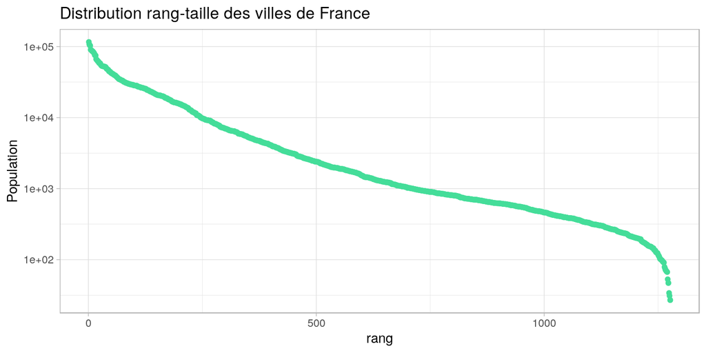

## Construction de la distribution théorique.

On commence par sommer les effectifs selon les modalités (en ligne et en colonne)

\[\begin{array}{c|c|c|c} & blanc & noir & \texttt{total}\\ \hline carré & 22 & 12 & 34\\ \hline rond & 10 & 30 & 40 \\ \hline triangle & 26 & 5 & 31\\ \hline \texttt{total} & 58 & 47 & 105 \end{array}\]

On appelle les sommes en lignes et en colonnes **sommes marginales**, elles sont mises dans les "marges" du tableau.